# Features of Youtube Ads

## How does being skippable affect the length of the ad?

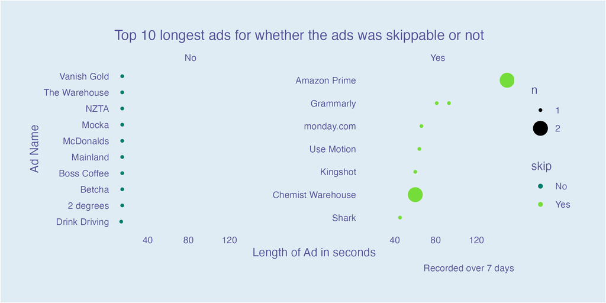

The ads have been ordered from longest to shortest within each group and we can see that the skippable ads are much longer than the unskippable ads. The maximum length of an ad if it was skippable is 150 seconds, while the longest unskippable ad is 15 seconds.

## Do videos with more views tend to have longer or shorter ads?

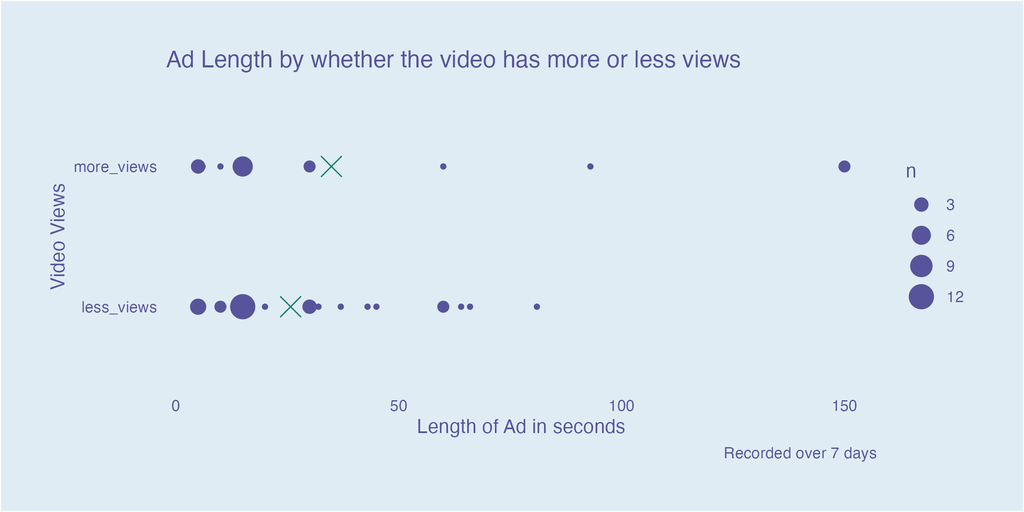

We have categorised the videos into more_views (number of views is greater than 500,000) and less views (number of views is less than 500,000). The points are scaled so that the size represents the number of observations with the same ad length. It doesn’t look like having more views affects the length of the ad massively as the points are relatively similarly distributed for both groups. The X symbol indicates the mean ad length for each category. Videos with more views have a mean ad length of 35 seconds, and videos with less views have a mean ad length of 26 seconds.

## Distribution of the actual ad watch time

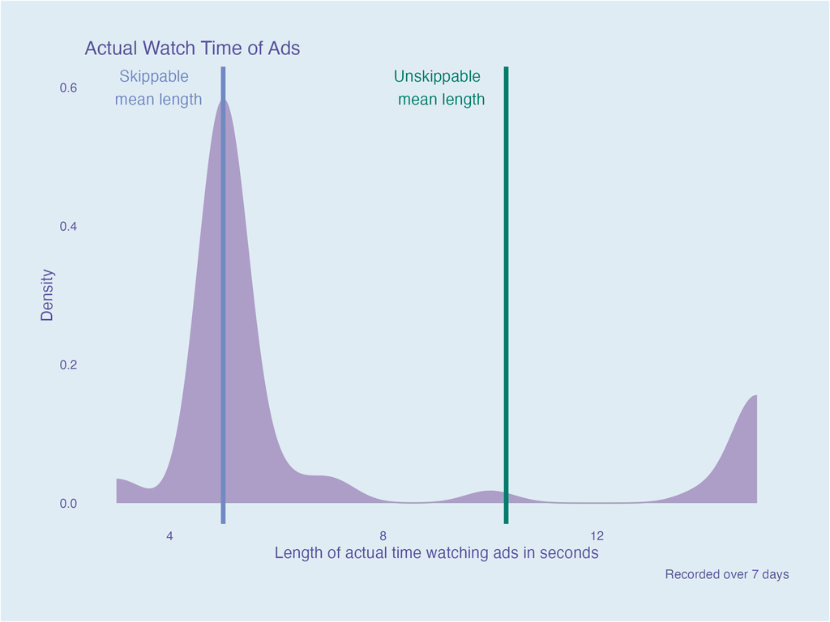

This is a density plot showing the distribution of the actual ad watch times. This is measured as the ad length for unskippable ads, and the length of time before a skip button is presented for skippable ads. Thus, this reflects the actual time a viewer would spend watching an ad. When skippable, the length of time spent watching the ad is 5 seconds, while the actual ad watch time when unskippable is 10 seconds. There is a big peak around the mean skippable ad length while the mean unskippable ad length is less obvious.

## In conclusion

Overall, we have learnt that while it appears like skippable ads have much longer ad length, the actual watch time tends to be lower than unskippable ads. Thus, skippable ads are long but they let you skip after around 5 seconds so we don’t actually spend a long time watching them. We’ve also discovered that videos with more views don’t necessarily have longer ads.

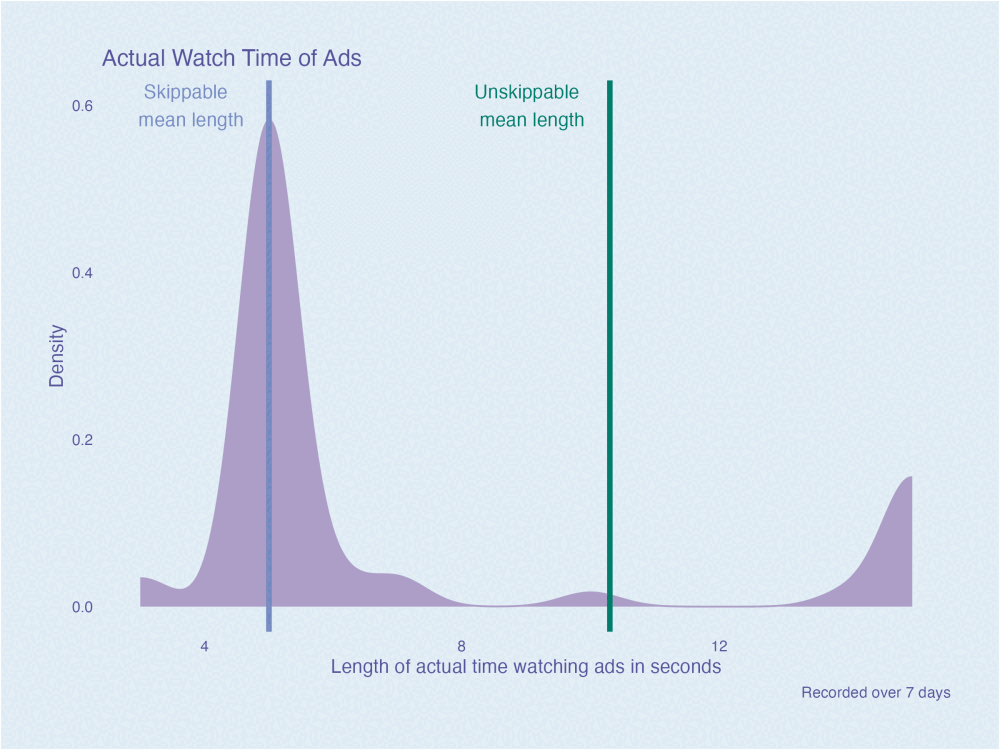

Animation of all the previous plots presented